# August2.2023_rmd_html

Sarah Eisenstein

2023-08-02

*## 1 Apply tidyverse tools (dplyr, ggplot2) to manipulate and visualize real world public data* As described in the README.md file, I am interested in substance use disorders and how they differ by gender and other factors such as socioeconomic status in the community. I sought to apply dplyr and ggplot2 tools to data I downloaded from Nutritional Health and Nutrition Examination Survey (NHANES, https://wwwn.cdc.gov/nchs/nhanes/).The income:family size ratio was used as a marker of degree of poverty (higher numbers = less poverty) and the substances considered in this exploratory project include marijuana, cocaine, heroin, and methamphetamine. There are 4 cohorts from different time points (year of survey participation) included: 2009-2010, 2011-2012, 2013-2014, 2015-2016. DATA IS NOT WEIGHTED BY DEMOGRAPHICS AND THEREFORE MAY NOT ACCURATELY REFLECT US CIVILIAN POPULATION (see https://wwwn.cdc.gov/nchs/data/nhanes/analyticguidelines/11-16-analytic-guidelines.pdf). Descriptions interpreting data are directly below plots.

*## 2 Packages Required*

```r
#for data wrangling; dplyr::select, mutate, select, recode
library(dplyr)
```

```r
#for data visualization with various plots
library(ggplot2)
```

*# 3 Dataset* For the current project, I focused on adults 18+ years, from cross-sectional cohorts assessed at 4 different time points (2009-2010, 2011-2012, 2013-2014, 2015-2016). Demographic (“Demographic Variables and Sample Weights” data file) and questionnaire (“Drug Use” data file) data. These data sets were merged in Power Query (inner join), saved as a csv file and imported into RStudio.

```r
#import dataset csv

library(readr)
use_this_July26_2023 <- read_csv("use_this_July26.2023.csv",
    col_types = cols(Year = col_factor(levels = c("2009_2010",
        "2011_2012", "2013_2014", "2015_2016")),
        RIAGENDR = col_factor(levels = c("1",
            "2")), RIDAGEYR = col_number(),
        INDFMPIR = col_number(), nhanes_drug_use_csv.DUQ200 = col_factor(levels = c("1",
            "2")), nhanes_drug_use_csv.DUQ210 = col_number(),
        nhanes_drug_use_csv.DUQ213 = col_number(),
        nhanes_drug_use_csv.DUQ230 = col_number(),
        nhanes_drug_use_csv.DUQ240 = col_factor(levels = c("1",
            "2")), nhanes_drug_use_csv.DUQ260 = col_number(),
        nhanes_drug_use_csv.DUQ280 = col_number(),
        nhanes_drug_use_csv.DUQ300 = col_number(),
        nhanes_drug_use_csv.DUQ320 = col_number(),
        nhanes_drug_use_csv.DUQ340 = col_number(),
        nhanes_drug_use_csv.DUQ360 = col_number()),
    na = "NA")
dataset<-use_this_July26_2023

dataset
```

```
## # A tibble: 19,997 × 52
##     SEQN Year    RIAGE…¹ RIDAG…² RIDRE…³ DMDED…⁴ WTINT…⁵ WTMEC…⁶ SDMVPSU SDMVS…⁷
##    <dbl> <fct>   <fct>     <dbl>   <dbl>   <dbl> <lgl>   <lgl>     <dbl>   <dbl>
##  1 52298 2009_2… 1            18      NA      NA NA      NA            1      78
##  2 53441 2009_2… 2            18      NA      NA NA      NA            2      88
##  3 54851 2009_2… 1            18      NA      NA NA      NA            1      81
##  4 55394 2009_2… 1            18      NA      NA NA      NA            2      78
##  5 55786 2009_2… 2            18      NA      NA NA      NA            2      78
##  6 56181 2009_2… 2            18      NA      NA NA      NA            2      75
##  7 56446 2009_2… 2            18      NA      NA NA      NA            2      85
##  8 56604 2009_2… 2            18      NA      NA NA      NA            1      76
##  9 57619 2009_2… 2            18      NA      NA NA      NA            2      77
## 10 59518 2009_2… 1            18      NA      NA NA      NA            2      82
## # … with 19,987 more rows, 42 more variables: INDFMPIR <dbl>, RIDRETH1 <dbl>,
## #   DMDEDUC3 <dbl>, WTINT2YR <dbl>, WTMEC2YR <dbl>,
## #   NHANES_physical_csv.BMXWT <dbl>, NHANES_physical_csv.BMXHT <dbl>,
## #   NHANES_physical_csv.BMXBMI <dbl>, NHANES_physical_csv.BMXWAIST <dbl>,
## #   NHANES_physical_csv.BMXTRI <dbl>, nhanes_drug_use_csv.DUQ200 <fct>,
## #   nhanes_drug_use_csv.DUQ210 <dbl>, nhanes_drug_use_csv.DUQ211 <dbl>,
## #   nhanes_drug_use_csv.DUQ213 <dbl>, nhanes_drug_use_csv.DUQ215Q <dbl>, …
```

```r
#name column variables for ease of use and understanding
dataset$Year -> year
dataset$RIAGENDR -> gender
dataset$RIDAGEYR -> age_years
dataset$INDFMPIR -> ratio_income_to_poverty_family
dataset$nhanes_drug_use_csv.DUQ200 -> mj_hashish_ever
dataset$nhanes_drug_use_csv.DUQ210 -> age_1st_mj_years
dataset$nhanes_drug_use_csv.DUQ213 -> age_start_reg_use_mj_years
dataset$nhanes_drug_use_csv.DUQ230 -> number_of_days_used_mj_in_last_month
dataset$nhanes_drug_use_csv.DUQ240 -> coc_her_meth_ever
dataset$nhanes_drug_use_csv.DUQ250 -> coc_ever
dataset$nhanes_drug_use_csv.DUQ260 -> age_1st_try_coc_years
dataset$nhanes_drug_use_csv.DUQ280 -> number_of_days_used_coc_in_last_month
dataset$nhanes_drug_use_csv.DUQ290 -> heroin_ever
dataset$nhanes_drug_use_csv.DUQ300 -> age_1st_her_years
dataset$nhanes_drug_use_csv.DUQ320 -> number_of_days_used_her_in_last_month
dataset$nhanes_drug_use_csv.DUQ330 -> meth_ever
dataset$nhanes_drug_use_csv.DUQ340 -> age_1st_meth_years
dataset$nhanes_drug_use_csv.DUQ360 -> number_of_days_used_meth_in_last_month
dataset$nhanes_drug_use_csv.DUQ370 -> needle_use_ever
```

```r
#Housekeeping

#change factor levels to labels where appropriate

levels(dataset$RIAGENDR) <- c('male', 'female')
levels(gender) <- c('male', 'female')
```

*# 4 Descriptive statistics and visualizations (NOT WEIGHTED BY DEMOGRAPHICS) for each drug of interest_____________________*

**#Marijuana________________________________________________________________________________________**

```r
##Descriptive statistics and boxplots

###Age first tried marijuana/hashish by gender (self-report, n = 19997-12583 = 7,414 participants)

dataset_by_gender <- dataset %>%
  group_by(RIAGENDR)

dataset_by_gender %>%
  summarize(mean_age_1st_mj_use = mean(nhanes_drug_use_csv.DUQ210, na.rm = TRUE),     sd_age_1st_mj = sd(nhanes_drug_use_csv.DUQ210, na.rm = TRUE))
```

```
## # A tibble: 2 × 3
##   RIAGENDR mean_age_1st_mj_use sd_age_1st_mj
##   <fct>                  <dbl>         <dbl>
## 1 male                    16.8          4.10
## 2 female                  17.4          4.48
```

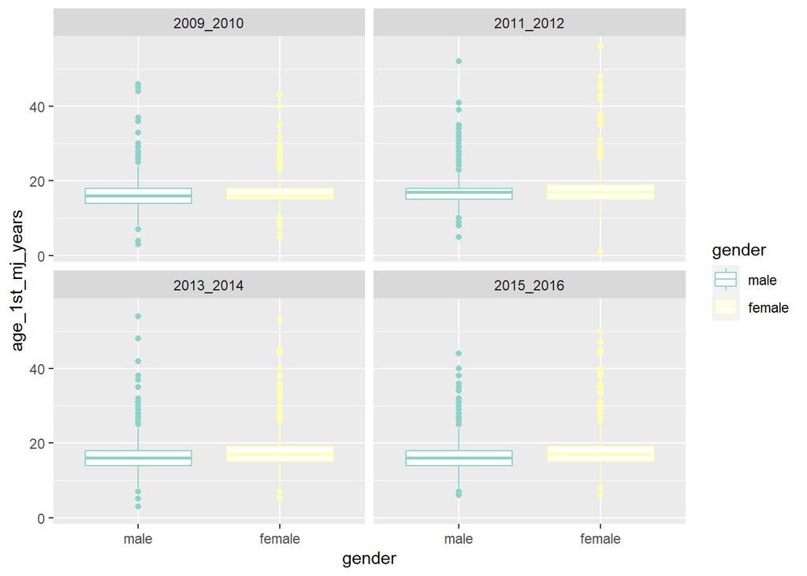

```r
ggplot(dataset, aes(x = gender, y = age_1st_mj_years, color = gender)) +
          geom_boxplot(na.rm = TRUE)+
        facet_wrap(year) +
        scale_color_brewer(palette = "Set3")
```

**Description of above:** Males and females both self-reported that they first tried marijuana/hashish ~age 17.However, many people in the sample reported first trying marijuana/hashish at older ages (up to ~age 50). This pattern was consistent across time points.

```r
###Age first regularly used marijuana/hashish by gender (self-report, n = 19997-16357 = 3640 participants)

dataset_by_gender %>%
  summarize(mean_age_reg_mj_use = mean(nhanes_drug_use_csv.DUQ213, na.rm = TRUE),     sd_age_reg_mj_use = sd(nhanes_drug_use_csv.DUQ213, na.rm = TRUE))
```

```
## # A tibble: 2 × 3
##   RIAGENDR mean_age_reg_mj_use sd_age_reg_mj_use
##   <fct>                  <dbl>             <dbl>
## 1 male                    17.3              4.05
## 2 female                  18.4              5.49
```

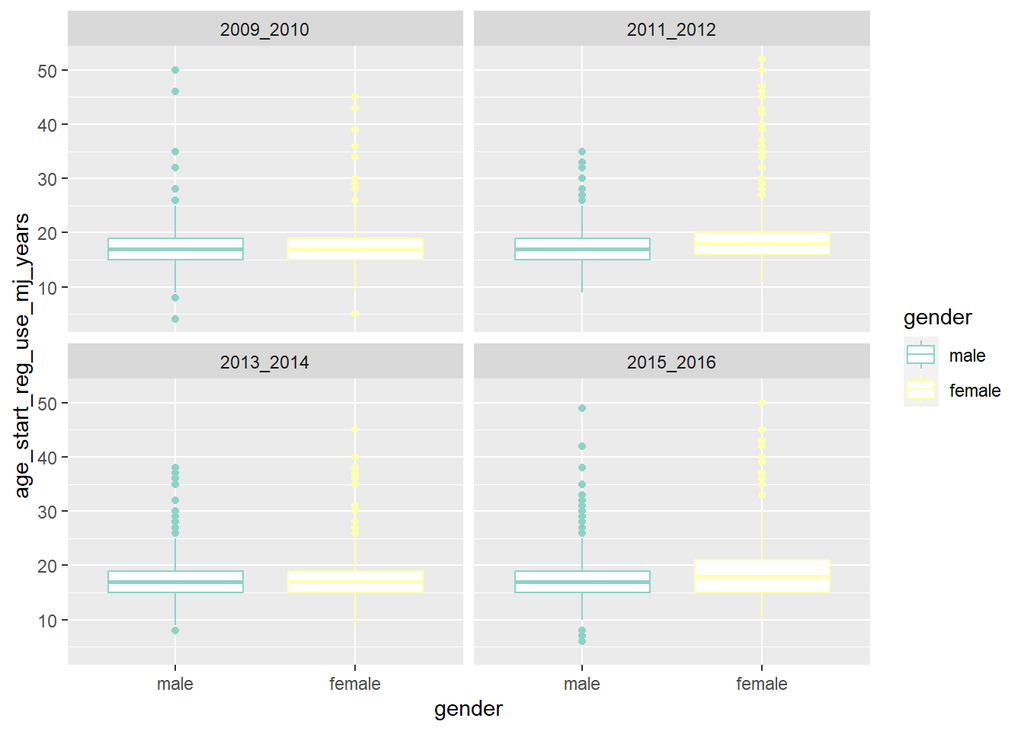

```r
ggplot(dataset, aes(x = gender, y = age_start_reg_use_mj_years, color = gender)) +
  geom_boxplot(na.rm = TRUE) +
  facet_wrap(year) +
  scale_color_brewer(palette = "Set3")
```

**Description of above:** Males and females self-reported becoming regular users of marijuana/hashish ~17 or 18 years, soon after trying it for the first time. This pattern was consistent across time points.

```r
###Number of days used marijuana/hashish in last month by gender (self-report, n = 19997-17836 = 2161 participants)

dataset_by_gender %>%
  summarize(mean_days_used_mj_in_last_mon = mean(nhanes_drug_use_csv.DUQ230, na.rm = TRUE),     sd_days_used_mj_in_last_mon = sd(nhanes_drug_use_csv.DUQ230, na.rm = TRUE))
```

```
## # A tibble: 2 × 3
##   RIAGENDR mean_days_used_mj_in_last_mon sd_days_used_mj_in_last_mon
##   <fct>                            <dbl>                       <dbl>
## 1 male                              13.2                        11.4
## 2 female                            11.3                        11.4
```

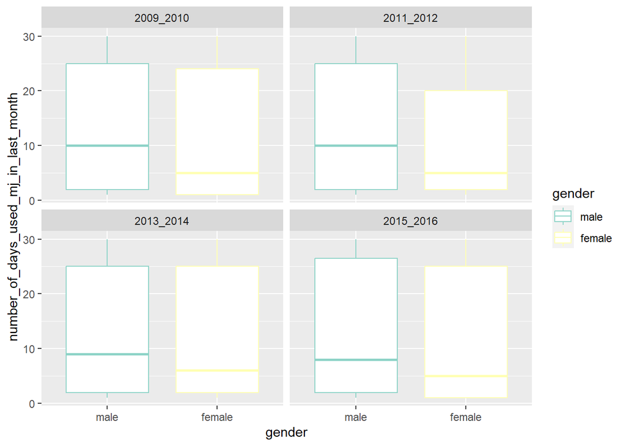

```r
ggplot(dataset, aes(x = gender, y = number_of_days_used_mj_in_last_month, color = gender)) +
  geom_boxplot(na.rm = TRUE) +
  facet_wrap(year) +
  scale_color_brewer(palette = "Set3")
```

**Description of above:** Males self-reported using marijuana/hashish slightly more past days (~13) during the last month than females (~11).This pattern was consistent across time points.

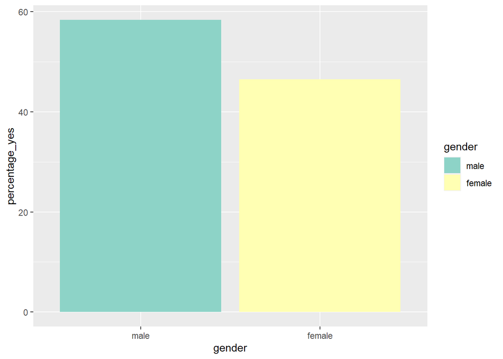

```r
##Bar plots

###Ever tried marijuana/hashish? (self-report, yes or no, n = 14183 participants)

percent_mj_use_by_gender <- dataset %>%
  filter(complete.cases(nhanes_drug_use_csv.DUQ200)) %>%
  count(RIAGENDR, nhanes_drug_use_csv.DUQ200)%>%
  group_by(RIAGENDR)%>%
  transmute(nhanes_drug_use_csv.DUQ200, Percentage=n/sum(n)*100)

percent_mj_use_ever <- percent_mj_use_by_gender %>%
  filter(nhanes_drug_use_csv.DUQ200 == 1)

percent_mj_use_ever$RIAGENDR -> gender
percent_mj_use_ever$Percentage -> percentage_yes

ggplot(percent_mj_use_ever, aes(x = gender, y = percentage_yes, fill = gender)) +
  geom_col(na.rm = TRUE) +
  scale_fill_brewer(palette = "Set3")
```

**Description of above:** More than half of males reported ever trying marijuana/hashish, while slightly less than half of females reported ever trying marijuana/hashish.

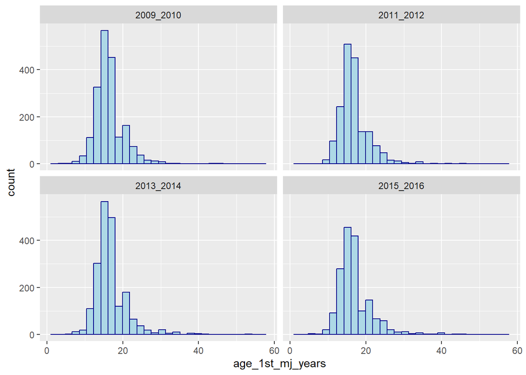

```r
##Histograms

###Age first tried marijuana/hashish? (self-report, n = 7414 participants)


ggplot(dataset, aes(x = age_1st_mj_years)) +
  geom_histogram(bins = 30,na.rm = TRUE, color = "darkblue", fill = "lightblue") +
  facet_wrap(year)
```

**Description of above:** Consistent with the box plots, most adults reported first trying marijuana/hashish in late teens/early twenties. However, the histogram is positively skewed, showing that some individuals were older when they first tried marijuana/hashish.These patterns are consistent across time points.

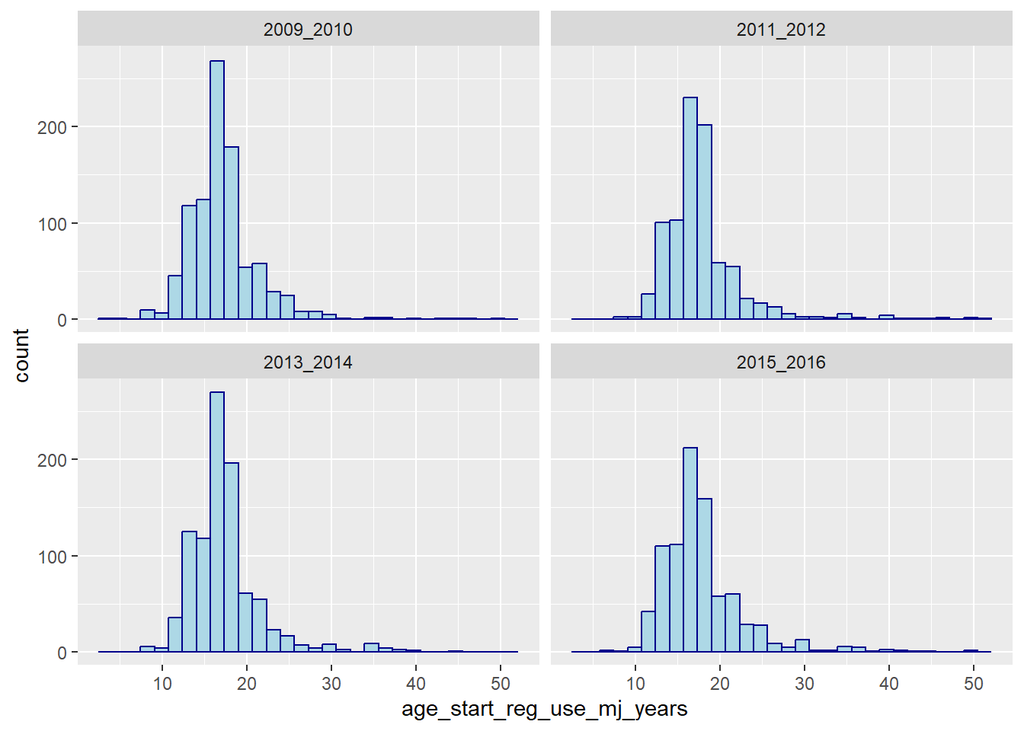

```r
###Age first started regularly using marijuana/hashish? (self-report, n = 3640 participants)

ggplot(dataset, aes(x = age_start_reg_use_mj_years)) +
  geom_histogram(bins = 30,na.rm = TRUE, color = "darkblue", fill = "lightblue") +
  facet_wrap(year)
```

**Description of above:** Similar to age at first use, most adults reported first becoming regular users of marijuana/hashish in late teens/early twenties. However, the histogram is positively skewed, showing that some individuals were older when they first became regular users.These patterns are consistent across time points.

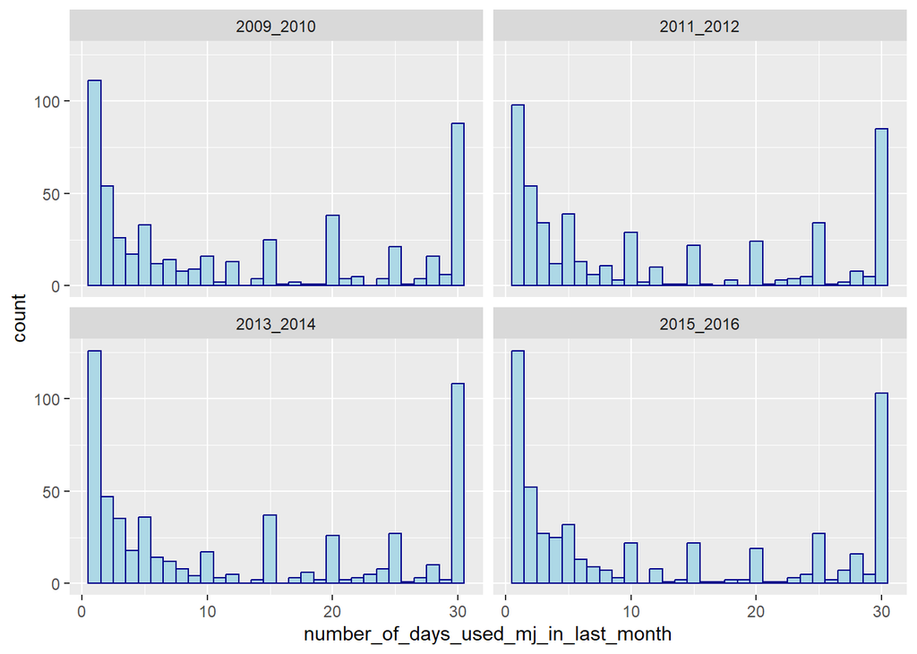

```r
##Number of days used marijuana/hashish in past month? (self-report, n = 2161 participants)

ggplot(dataset, aes(x = number_of_days_used_mj_in_last_month)) +
  geom_histogram(bins = 30,na.rm = TRUE, color = "darkblue", fill = "lightblue") +
  facet_wrap(year)
```

**Description of above:** Interestingly, current users of marijuana/hashsish reported a wide range of use during the past month, with many reporting one day of use and many reporting using every day. This pattern is consistent over each time point.

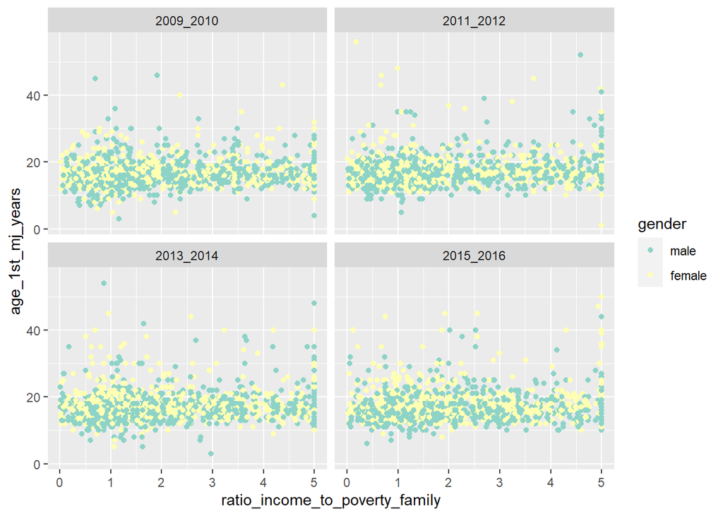

```r
##Further exploration with scatterplots: income:family size ratio (higher is less poverty) and gender

dataset$RIAGENDR -> gender

ggplot(dataset,aes(x = ratio_income_to_poverty_family, y = age_1st_mj_years, color = gender)) +
  geom_point(na.rm = TRUE) +
  facet_wrap(year) +
  scale_color_brewer(palette = "Set3")
```

**Description of above:** Regardless of income:family size ratio (where higher values = less poverty), men and women tended to try marijuana/hashish at late teens/early twenties. This pattern was consistent over time points.

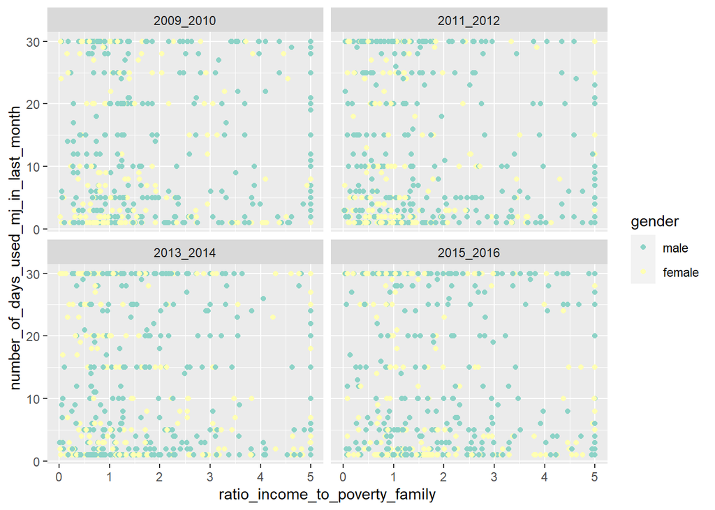

```r
ggplot(dataset, aes(x = ratio_income_to_poverty_family, y = number_of_days_used_mj_in_last_month, color = gender) ) +
  geom_point(na.rm = TRUE) +
  facet_wrap(year) +
  scale_color_brewer(palette = "Set3")
```

**Description of above:** Unlike first age at trying marijuana/hashish, current self-reported lower income:family size ratio (where higher values = less poverty) tended to relate to a higher number of days of use over the past month in men and women. This pattern was consistent over time points. $~$ **#Cocaine__________________________________________________________________________________________**

```r
##Descriptive statistics and boxplots

###Age first tried cocaine by gender (self-report, n = 19997-17698 = 2299 participants)

dataset_by_gender <- dataset %>%
  group_by(RIAGENDR)

dataset_by_gender %>%
  summarize(mean_age_1st_cocaine_use = mean(nhanes_drug_use_csv.DUQ260, na.rm = TRUE),     sd_age_1st_mj = sd(nhanes_drug_use_csv.DUQ260, na.rm = TRUE))
```

```
## # A tibble: 2 × 3
##   RIAGENDR mean_age_1st_cocaine_use sd_age_1st_mj
##   <fct>                       <dbl>         <dbl>
## 1 male                         21.5          5.53
## 2 female                       21.7          6.00
```

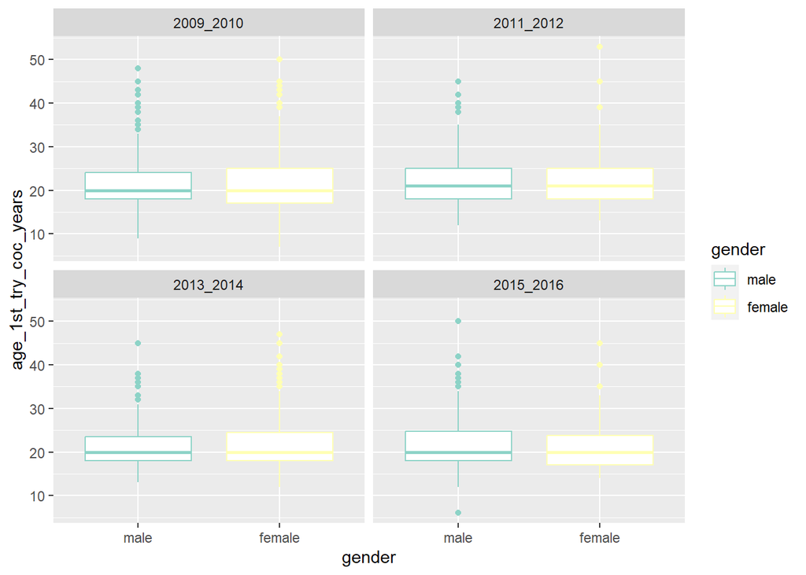

```r
ggplot(dataset, aes(x = gender, y = age_1st_try_coc_years, color = gender)) +
  geom_boxplot(na.rm = TRUE) +
  facet_wrap(year) +
  scale_color_brewer(palette = "Set3")
```

**Description of above:** Both men and women reported being a few years older (~22) when first trying cocaine as compared to first trying marijuana/hashish. This pattern was consistent over time points.

```r
###Number of days used cocaine in last month by gender (self-report, n = 19997-19760 = 237 participants)

dataset_by_gender %>%
  summarize(mean_days_used_cocaine_in_last_mon = mean(nhanes_drug_use_csv.DUQ280, na.rm = TRUE),sd_days_used_mj_in_last_mon = sd(nhanes_drug_use_csv.DUQ280, na.rm = TRUE))
```

```
## # A tibble: 2 × 3
##   RIAGENDR mean_days_used_cocaine_in_last_mon sd_days_used_mj_in_last_mon
##   <fct>                                 <dbl>                       <dbl>
## 1 male                                   3.99                        5.60
## 2 female                                 4.95                        6.08
```

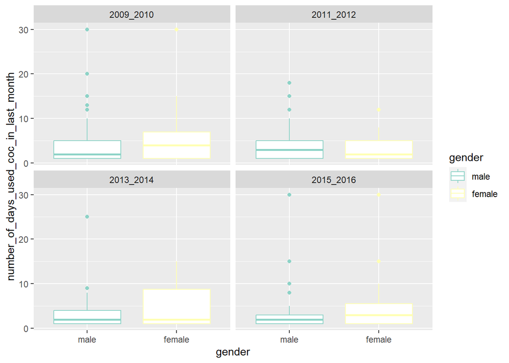

```r
ggplot(dataset, aes(x = gender, y = number_of_days_used_coc_in_last_month, color = gender)) +
  geom_boxplot(na.rm = TRUE) +
  facet_wrap(year) +
  scale_color_brewer(palette = "Set3")
```

**Description of above:** Unlike marijuana/hashish, men and women self-reported using cocaine consistently fewer days (~4-5) during the past month. Some individuals did report using cocaine more often during the past month, especially at the first time point (2009-2010).

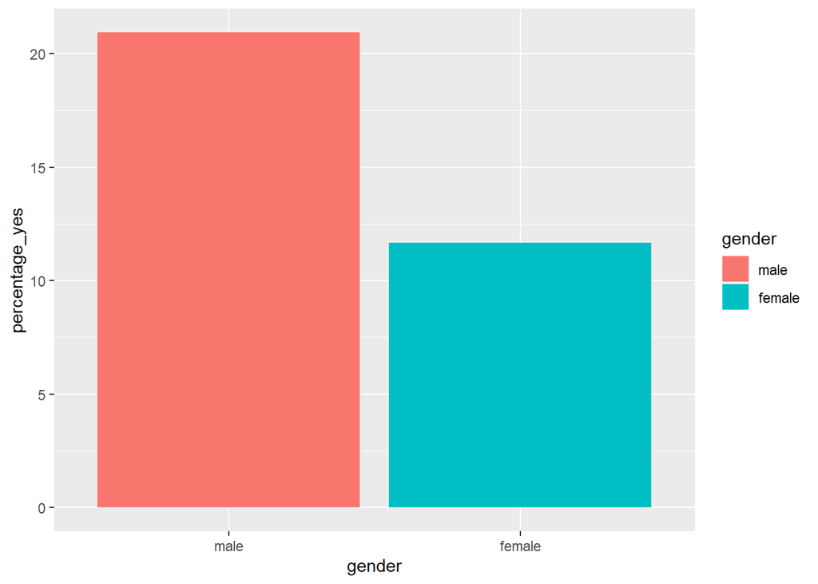

```r
##Bar plots

###Ever tried cocaine, heroin and/or methamphetamines? (self-report, yes or no)

percent_polydrug_use_by_gender <- dataset %>%
  filter(complete.cases(nhanes_drug_use_csv.DUQ240)) %>%
  count(RIAGENDR, nhanes_drug_use_csv.DUQ240)%>%
  group_by(RIAGENDR)%>%
  transmute(nhanes_drug_use_csv.DUQ240, Percentage=n/sum(n)*100)

percent_polydrug_use_ever <- percent_polydrug_use_by_gender %>%
  filter(nhanes_drug_use_csv.DUQ240 == 1)

percent_polydrug_use_ever$RIAGENDR -> gender
percent_polydrug_use_ever$Percentage -> percentage_yes

ggplot(percent_polydrug_use_ever, aes(x = gender, y = percentage_yes, fill = gender)) +
  geom_col() +
  scale_color_brewer(palette = "Set3")
```

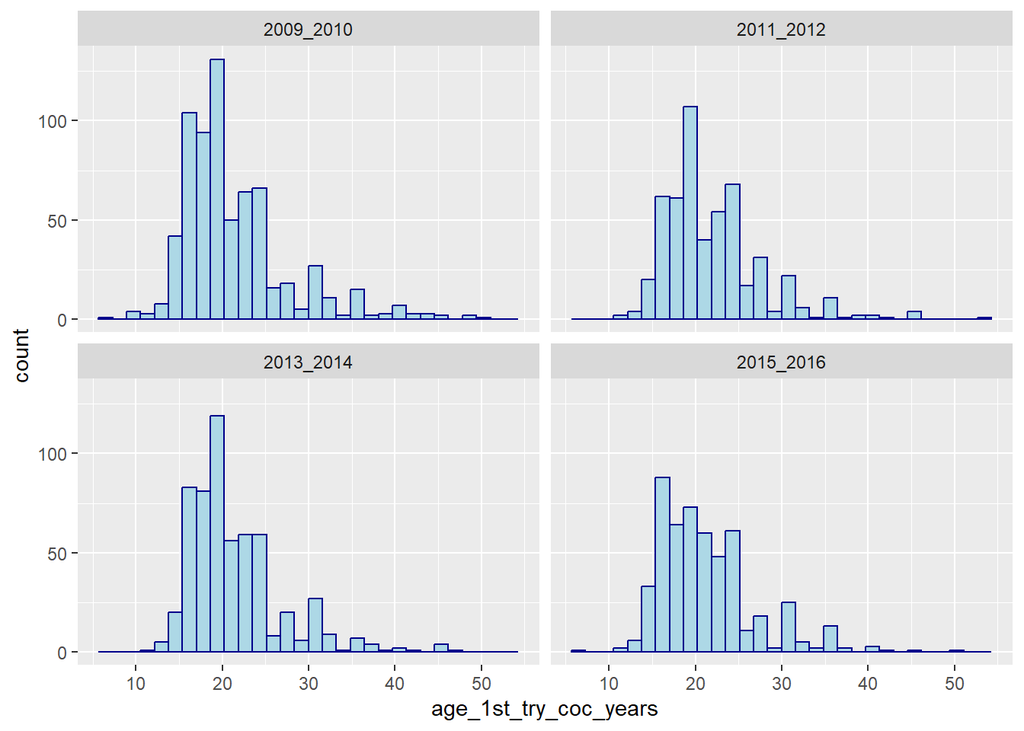

```r
##Histograms

###Age first tried cocaine? (self-report, n =  19997 - 17698 = 2299 participants)

ggplot(dataset, aes(x = age_1st_try_coc_years)) +
  geom_histogram(bins = 30, na.rm = TRUE,color = "darkblue", fill = "lightblue" )+
  facet_wrap(year)
```

**Description of above:** As the boxplots showed, people tended to report first trying cocaine in their early twenties. Similar to marijuana/hashish, the distribution is positively skewed, indicating some adults reported first trying cocaine at older ages. These patters were similar across time points.

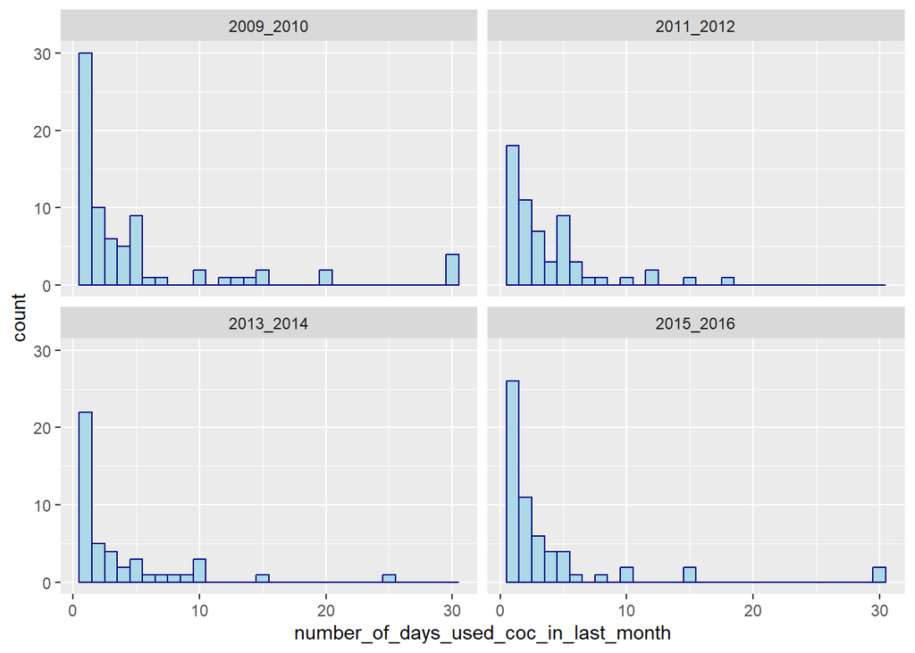

```r
##Number of days used cocaine in past month? (self-report, n = 19997 - 19760 = 237 participants)

ggplot(dataset, aes(x = number_of_days_used_coc_in_last_month)) +
  geom_histogram(bins = 30, na.rm = TRUE, color = "darkblue", fill = "lightblue") +
  facet_wrap(year)
```

**Description of above:** As the boxplots showed, cocaine use was reported as used less than 10 days during the past month by most participants. This was consistent across time points.

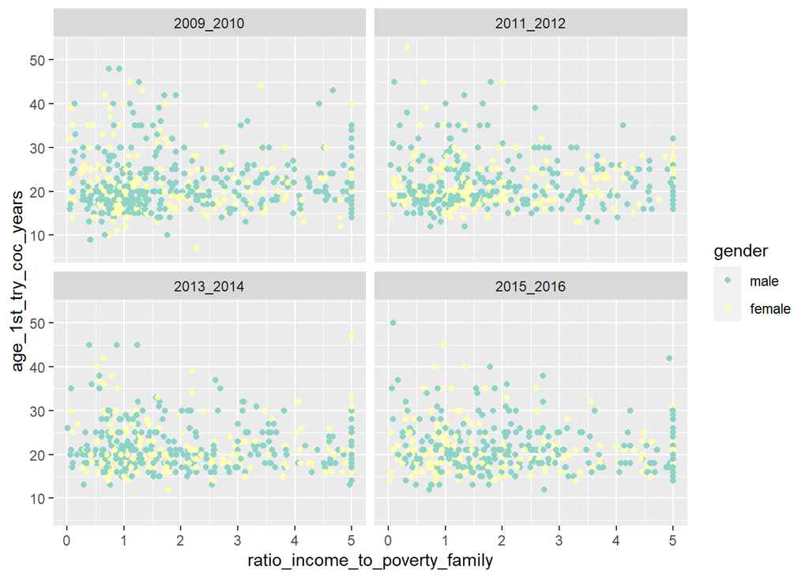

```r
##Further exploration with scatterplots: income:family size ratio (higher is less poverty) and gender

dataset$RIAGENDR -> gender #re-run this line, otherwise error results: "problem while computing aesthetics"

ggplot(dataset, aes(x = ratio_income_to_poverty_family, y = age_1st_try_coc_years, color = gender)) +
  geom_point(na.rm = TRUE) +
  facet_wrap(year) +
  scale_color_brewer(palette = "Set3")
```

**Description of above:** Unlike marijuana/hashish, men and women who reported first trying cocaine during their younger years tended to have lower current income:family size ratio. However, the pattern is subtle and it should be noted that this a small sample size. No statistics have been performed to test whether this relationship is statistically significant. The pattern tends to be similar across time points.

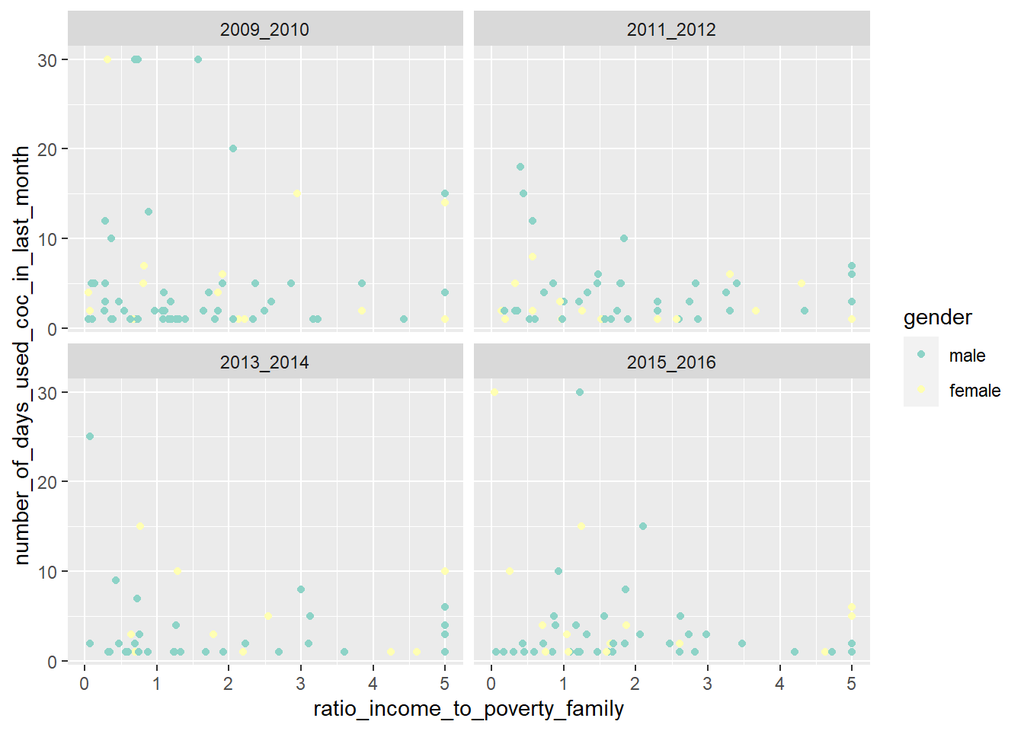

```r
ggplot(dataset, aes(x = ratio_income_to_poverty_family, y = number_of_days_used_coc_in_last_month, color = gender)) +
  geom_point(na.rm = TRUE) +
  facet_wrap(year) +
  scale_color_brewer(palette = "Set3")
```

**Description of above:** Similar to marijuana/hashish, there appears to be a relationship between greater reported number of days that cocaine was used and lower current income:family size ratio. Note this is a small sample and no statistical analysis has been done. The pattern is similar across time points.